# Yoga Power

Jessica Sanders, Mona Iwamoto, Boris Kletser, Amy Lai

June 21, 2017

## Experimental Design - Yoga in Schools

The proposed experiment will be conducted at an elementary school located in Atlanta, GA whose principal and many teachers are trained in teaching yoga to children. They serve Kindergarten through 5th grade.

One or two classrooms from each grade will be randomly selected (block selection). Then all students will be exposed to the various treatments. Classroom sizes are anticipated to be between 20-30 students. Treatment classrooms will be given a child-appropriate session of yoga, followed by a short memory recall task. Control classes will do standard classroom activities followed by the recall task.

## Power Simulation

The following code calculates the expected power of the experiment based on number of grades targeted, classrooms treated, and students per class. As we have not finalized the details of the outcome metric, the calcuations are done with normalized outcomes. Within a given grade potential outcomes to control are simulated to be distributed normally with a mean of 0 and an standard deviation of 1. It is assumed that outcome to control is linearly related to grade level. The variable $te$ indicates the treatment effect in standard deviations.

List of assumptions (these can be modified if necessary):

1. Every class has the same number of students
2. There is a linear effect of grade on outcomes, with a coefficient of one standard deviation
3. The between class variation is small (based on noise with a standard devation of 0.2)
4. The treatment effect is constant

### Set up the environment

```r
library(data.table)
rm(list = ls())
```

## Set some experimental parameters

```r
# Number of grades
nGrades <- 3
# Number of classrooms per grade
nClassrooms <- 4
# Number of classes per grade to treat
nClassTreat <- 2
# Number of students per classroom
nStudents <- 20
```

Given the experimental setup and an average treatment effect, this function simulates the experiment and returns either (a) the estimated average treatment effect (ATE), (b) the ATE and associated standard error, or (c) the t-statistic. We are assuming we have access to the full schedule of potential outcomes (that’s why this is a simulation, yo).

The experimental setup is *both* blocked (on grade level) and clustered (class level treatment assignment), so the most challenging part of this simulation is the computation of the standard errors. Below I use clustered standard errors (Gerber and Green equation 3.22) within a grade level and them accumulate them as blocks (Gerber and Green equation 3.12).

```r
simPowerData <- function(nGrades = 6,
                         nClassrooms = 4,
                         nClassTreat = 2,
                         nStudents = 20,
                         te = 1,
                         calcSE=TRUE,
                         returnT = TRUE) {


  # Assume there is a linear relationship between grade level and outcome to control.
  # Alpha is the coefficient on the grade level
  alpha <- 1

  # Total number of kids participating
  N <- nGrades*nClassrooms*nStudents

  # Number of classes per grade that get left to control
  nClassControl <- nClassrooms - nClassTreat

  # Create an vector with grade values (K=0)
  allGrades <- c(0:(nGrades-1))

  # Create columns for grade and classroom IDS
  gradeIDs <- rep(0:(nGrades-1), each = nClassrooms*nStudents)
  classroomIDs <- rep(1:(nGrades*nClassrooms), each = nStudents)

  # Create models of the outcome to control
  # including the variation between grades and classroom

  gradeLevelNoise <- alpha*allGrades
  classLevelNoise <- rnorm(n = nGrades*nClassrooms, mean = 0, sd = 0.2)

  # The outcome to control for individuals is the individual variation plus class level noise
  # plus grade level noise
  y0 <- rnorm(N, mean = 0, sd = 1) + gradeLevelNoise[gradeIDs+1] + classLevelNoise[classroomIDs]

  # Assume the treatment effect is one standard deviation
  y1 <- y0 + te

  # Create the treatment vectors

  # This statement is kind of ridiculous, but it creates a treatment vector for classrooms
  # that is blocked on grades
  classTreat <- as.vector(replicate(nGrades, sample(c(rep(1, nClassTreat), rep(0, nClassControl)))))

  # Expand into the treatment vector for individual students
  studentTreat <- rep(classTreat, each=nStudents)

  # Create  a data table with all our subjects
  d = data.table(id = 1:N)
  d[,gradeIDS := gradeIDs]
  d[,classroomIDs := classroomIDs]
  d[,y0 := y0]
  d[,y1 := y1]
  d[,treat := studentTreat]
  d[,y := ifelse(treat==1, y1, y0)]

  ## ------------------------------------
  ## calc estimated ATE and outcome means
  ## ------------------------------------
  ate = d[ , mean(y[treat==1]) - mean(y[treat==0])]

  ## -----------------------------
  ## calculate the standard errors
  ## -----------------------------

  if(calcSE) {
    ## Initialize the standard error
    se <- 0
    for (i in 0:(nGrades-1)) {

      ## -----------------------------------------------------
      ## Calculate the clustered standard error for that grade
      ## -----------------------------------------------------

      # Get the parameters
      kGrade <- nClassrooms
      NGrade <- nClassrooms*nStudents
      mGrade <- nClassTreat*nStudents

      ## Collect the means of y0 and y1 in every classroom in this grade
      uniqueclassrooms <- unique(d[ , classroomIDs[gradeIDs == i]])
      meanY0 <- c()
      meanY1 <- c()
      for (j in uniqueclassrooms) {
        meanY0 <- append(meanY0, mean(d[, y0[classroomIDs == j]]))
        meanY1 <- append(meanY1, mean(d[, y1[classroomIDs == j]]))
      }

      # Get the variance of the means
      varY0 <- var(meanY0)
      varY1 <- var(meanY1)
      covY0Y1 <- cov(meanY0,meanY1)

      # Clustered standard errors - Gerber and Green (3.22)
      seGrade <- sqrt( 1/(kGrade-1)*( mGrade*varY0/(NGrade-mGrade) + (NGrade-mGrade)*varY1/mGrade + 2*covY0Y1) )

      # Blocked standard errors - Gerber and Green (3.12) (under the sqrt)
      se <- se + (NGrade*seGrade/N)**2
    }

    se <- sqrt(se)
    t = ate/se
    ans <- c(ate,se)

    if(returnT)  {
      return(t)
    } else {
    return(ans)
    }

  } else {
    return(ate)
  }
}
```

We can run the simulation of the experiment a single time to see what there is to see. What is the ATE and associated standard error we get out? Let’s try a treatment effect of 0.4 standard deviations.

```r
myStats <- simPowerData(nGrades = 6,
                        nClassrooms = 4,
                        nClassTreat = 2,
                        nStudents = 20,
                        te=0.4,
                        calcSE=TRUE,
                        returnT=FALSE)

cat("Real treatment effect = ", 0.4)
```

```
## Real treatment effect =  0.4
```

```r
cat("Estimated treatment effect = ",myStats[1])
```

```
## Estimated treatment effect =  0.526872
```

```r
cat("Standard error = ",myStats[2])
```

```
## Standard error =  0.1382919
```

A second option for calcuating the standard errors is to generate a sampling distribution and get the standard deviation. We can see if this squares with what we’re seeing from the calculation

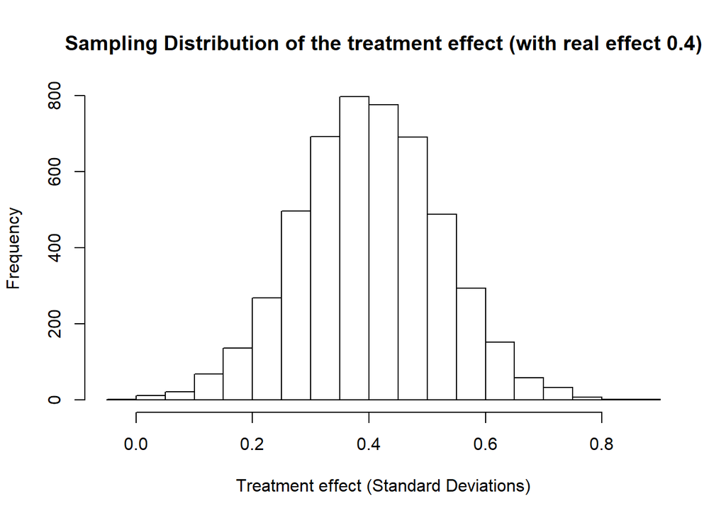

```r
# Number of trials to run
trials = 5000

# Get the sampling distribution
trialATEs <- replicate(trials, simPowerData(nGrades = 6,
                                            nClassrooms = 4,
                                            nClassTreat = 2,
                                            nStudents = 20,
                                            te=0.4,
                                            calcSE=FALSE,
                                            returnT=FALSE))

# Print a histogram
hist(trialATEs, main="Sampling Distribution of the treatment effect (with real effect 0.4)",
                xlab="Treatment effect (Standard Deviations)")
```

```r
# ... and pull out the standard deviation
mySE <- sd(trialATEs)

cat("Estimated standard error =", mySE)
```

```
## Estimated standard error = 0.1216583
```

Turn our attention to power:

```r
## To simulate this, just run it a bunch of times, gather up the t.stats
## from each run, and compare it to the critical value we're interested in.

# Here is the critical t-statistic we're interested in
critValue <- function(alpha, N) {
    critValue = qt(p = 1 - (alpha / 2), df = N)
    return(critValue)
}

cat("Critical t-statistic = ", critValue(0.05, nGrades*nClassrooms*nStudents))
```

```
## Critical t-statistic =  1.969898
```

```r
## Wrap both these up into a nice little bow...
simPower <- function(sims, nGrades, nClassrooms,nClassTreat,nStudents,te) {
    res <-  replicate(n = sims, simPowerData(nGrades=nGrades,
                                             nClassrooms=nClassrooms,
                                             nClassTreat=nClassTreat,
                                             nStudents=nStudents,
                                             te=te,
                                             calcSE=TRUE,
                                             returnT=TRUE) )
    print(prop.table(table(res < critValue(alpha=0.05, N=nGrades*nClassrooms*nStudents))))
}

simPower(sims=1000,
         nGrades=nGrades,
         nClassrooms=nClassrooms,
         nClassTreat=nClassTreat,
         nStudents=nStudents,
         te = 0.4)
```

```
##
## FALSE  TRUE
## 0.569 0.431
```